# Questions

## Dimentionality reduction with tSNE on VGG16_probabilities

```python
tsne = manifold.TSNE(n_components=2, perplexity=20,
                     n_iter=2000, init='random', learning_rate='auto')

vgg16_full_trans_tsne = tsne.fit_transform(vgg16_full_trans)
df_VGG_full = pd.DataFrame(vgg16_full_trans_tsne[:,0:2], columns=['tsne1', 'tsne2'])

# X_tsne_full = tsne.fit_transform(VGG16_probabilities) # the ARI isn't any better
# df_VGG_full = pd.DataFrame(X_tsne_full[:,0:2], columns=['tsne1', 'tsne2'])

print(df_VGG_full.shape)
```

```
(1050, 2)
```

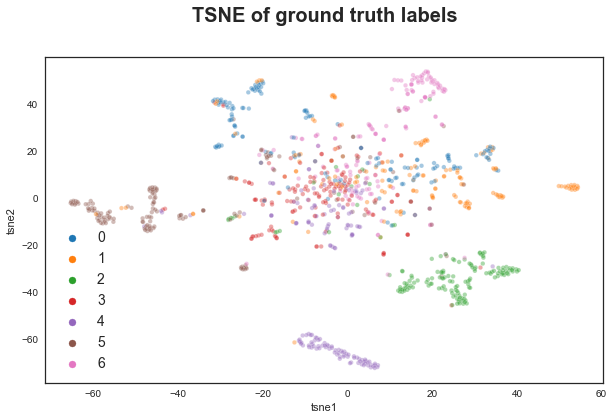

```python
plt.figure(figsize=(10,6))
sns.scatterplot(
    x='tsne1', y='tsne2',
    hue=orig_labels,
    palette=sns.color_palette('tab10', n_colors=7), s=20, alpha=0.4,
    data=df_VGG_full,
    legend='brief')

plt.title('TSNE of ground truth labels', fontsize = 20, pad = 35, fontweight = 'bold')
# plt.xlabel('tsne1', fontsize=16, fontweight = 'bold')
# plt.ylabel('tsne2', fontsize=16, fontweight = 'bold')
plt.legend(prop={'size': 14})

plt.show()
```

```python
kmeans = cluster.KMeans(n_clusters=7)
kmeans.fit(vgg16_full_trans_tsne)

VGG16_full_tsne_labels = kmeans.labels_
df_VGG_full['tsne_labels'] = kmeans.labels_
print(df_VGG_full.shape)
```

```
(1050, 3)
```

```python
print('ARI of KMeans labels', metrics.adjusted_rand_score(orig_labels, VGG16_full_tsne_labels))
print('AMutual Info score of KMeans labels', metrics.adjusted_mutual_info_score(orig_labels, VGG16_full_tsne_labels))
print('Homogeneity score of KMeans labels', metrics.homogeneity_score(orig_labels, VGG16_full_tsne_labels))
print('Completeness score of KMeans labels', metrics.completeness_score(orig_labels, VGG16_full_tsne_labels))
print('Fowlkes Mallows score of KMeans labels', metrics.fowlkes_mallows_score(orig_labels, VGG16_full_tsne_labels))
print('Silhouette score of KMeans labels', metrics.silhouette_score(vgg16_full_trans_tsne, VGG16_full_tsne_labels))
print('Davies-Bouldin index of KMeans labels', metrics.davies_bouldin_score(vgg16_full_trans_tsne, VGG16_full_tsne_labels)) # when use redu_spa, TypeError: A sparse matrix was passed, but dense data is required. Use X.toarray() to convert to a dense numpy array.
print('Calinski-Harabasz score of KMeans labels', metrics.calinski_harabasz_score(vgg16_full_trans_tsne, VGG16_full_tsne_labels)) # when use redu_spa, TypeError: A sparse matrix was passed, but dense data is required. Use X.toarray() to convert to a dense numpy array.
```

```
ARI of KMeans labels 0.34452709047647334
AMutual Info score of KMeans labels 0.47292791630367687
Homogeneity score of KMeans labels 0.4644362135237699
Completeness score of KMeans labels 0.4918826524562433
Fowlkes Mallows score of KMeans labels 0.45153212759563927
Silhouette score of KMeans labels 0.50214916
Davies-Bouldin index of KMeans labels 0.6347869560431587
Calinski-Harabasz score of KMeans labels 1353.348364726899
```

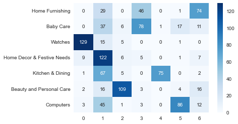

```python
conf_mat = metrics.confusion_matrix(orig_labels, VGG16_full_tsne_labels)
df_cm = pd.DataFrame(conf_mat, index = [label for label in labels_names])
plt.figure()
ax3 = sns.heatmap(df_cm, annot=True, cmap='Blues', fmt='g')
plt.show()
```

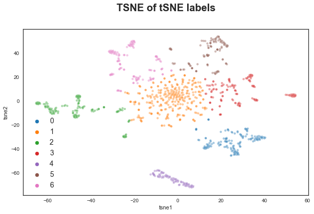

```python
plt.figure(figsize=(10,6))
sns.scatterplot(
    x='tsne1', y='tsne2',
    hue='tsne_labels',
    palette=sns.color_palette('tab10', n_colors=7), s=20, alpha=0.4,
    data=df_VGG_full,
    legend='brief')

plt.title('TSNE of tSNE labels', fontsize = 20, pad = 35, fontweight = 'bold')
# plt.xlabel('tsne1', fontsize=16, fontweight = 'bold')
# plt.ylabel('tsne2', fontsize=16, fontweight = 'bold')
plt.legend(prop={'size': 14})

plt.show()
```

The result of the image clustering is poorer than that of text treatment.

Between SIFT and VGG16, VGG 16 gives better metrics.

# Pre-trained VGG16 with all layers but last one (without the classifier)

This approach allows to recover the features - the vectors of 4096 values. Then the approach is the same: dimensionality reduction (this can be done with PCA, TSNE, or something else (maybe NMF for positive values), clustering, evaluation.

```python
# vgg16_model = VGG16()
my_model = models.Sequential()

for layer in vgg16_model.layers[:-1]:
    my_model.add(layer)

# Freeze the layers
for layer in my_model.layers:
    layer.trainable = False

# # Add 'softmax' instead of earlier 'prediction' layer
# # THIS WE CAN DO WITH CLASSIFICATION BUT NOT WITH A CLUSTERING
# my_model.add(Dense(7, activation='softmax'))
```

```python
time1 = time.time()
test5 = test3.map(lambda x: my_model.predict(x))

print(f'prediction of 4096 features for 1050 images is done in {time.time() - time1} seconds.')
```

```
prediction of 4096 features for 1050 images is done in 299.21278166770935 seconds.
```

```python
test5 = test5.map(lambda x: x[0]) #remove the "envelop" of the array; convert a collection to a single image
```

```python
VGG16_features = np.stack(test5.values)
VGG16_features.shape
```

```
(1050, 4096)
```

## Dimentionality reduction with PCA on VGG16_features

```python
pca = PCA(n_components=0.99)
```

```python
vgg16_part_trans = pca.fit_transform(VGG16_features)
vgg16_part_trans.shape
```

```
(1050, 803)
```

```python
# clustering with KMeans on image array
kmeans = cluster.KMeans(n_clusters=7)
kmeans.fit(vgg16_part_trans)
VGG16_part_pca_labels = kmeans.labels_

kmeans = cluster.KMeans(n_clusters=7)
kmeans.fit(VGG16_features) # ARI or silhouette ar both merely the same that with PCA, actually even a bit worse
VGG16_part_labels = kmeans.labels_
```

```python
conf_mat = metrics.confusion_matrix(orig_labels, VGG16_part_pca_labels)
print('ARI of KMeans labels', metrics.adjusted_rand_score(orig_labels, VGG16_part_pca_labels))
print('AMutual Info score of KMeans labels', metrics.adjusted_mutual_info_score(orig_labels, VGG16_part_pca_labels))
print('Homogeneity score of KMeans labels', metrics.homogeneity_score(orig_labels, VGG16_part_pca_labels))
print('Completeness score of KMeans labels', metrics.completeness_score(orig_labels, VGG16_part_pca_labels))
print('Fowlkes Mallows score of KMeans labels', metrics.fowlkes_mallows_score(orig_labels, VGG16_part_pca_labels))
print('Silhouette score of KMeans labels', metrics.silhouette_score(vgg16_part_trans, VGG16_part_pca_labels))
print('Davies-Bouldin index of KMeans labels', metrics.davies_bouldin_score(vgg16_part_trans, VGG16_part_pca_labels)) # when use redu_spa, TypeError: A sparse matrix was passed, but dense data is required. Use X.toarray() to convert to a dense numpy array.
print('Calinski-Harabasz score of KMeans labels', metrics.calinski_harabasz_score(vgg16_part_trans, VGG16_part_pca_labels)) # when use redu_spa, TypeError: A sparse matrix was passed, but dense data is required. Use X.toarray() to convert to a dense numpy array.
```

```
ARI of KMeans labels 0.4895959014363267
AMutual Info score of KMeans labels 0.6039861528142234
Homogeneity score of KMeans labels 0.5917070727169949
Completeness score of KMeans labels 0.6244052208339724
Fowlkes Mallows score of KMeans labels 0.5714993316027139
Silhouette score of KMeans labels 0.087336846
Davies-Bouldin index of KMeans labels 3.067064632505066
Calinski-Harabasz score of KMeans labels 50.106078571184305
```

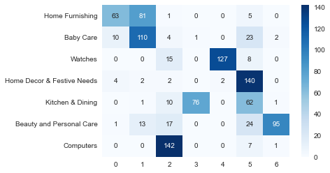

```python
df_cm = pd.DataFrame(conf_mat, index = [label for label in labels_names])
plt.figure()
ax3 = sns.heatmap(df_cm, annot=True, cmap='Blues', fmt='g')
plt.show()
```

```python
conf_mat = metrics.confusion_matrix(orig_labels, VGG16_part_labels)
print('ARI of KMeans labels', metrics.adjusted_rand_score(orig_labels, VGG16_part_labels))
print('AMutual Info score of KMeans labels', metrics.adjusted_mutual_info_score(orig_labels, VGG16_part_labels))
print('Homogeneity score of KMeans labels', metrics.homogeneity_score(orig_labels, VGG16_part_labels))
print('Completeness score of KMeans labels', metrics.completeness_score(orig_labels, VGG16_part_labels))
print('Fowlkes Mallows score of KMeans labels', metrics.fowlkes_mallows_score(orig_labels, VGG16_part_labels))
print('Silhouette score of KMeans labels', metrics.silhouette_score(VGG16_features, VGG16_part_labels))
print('Davies-Bouldin index of KMeans labels', metrics.davies_bouldin_score(VGG16_features, VGG16_part_labels)) # when use redu_spa, TypeError: A sparse matrix was passed, but dense data is required. Use X.toarray() to convert to a dense numpy array.
print('Calinski-Harabasz score of KMeans labels', metrics.calinski_harabasz_score(VGG16_features, VGG16_part_labels)) # when use redu_spa, TypeError: A sparse matrix was passed, but dense data is required. Use X.toarray() to convert to a dense numpy array.
```

```
ARI of KMeans labels 0.4811041368993192
AMutual Info score of KMeans labels 0.5971047365818293
Homogeneity score of KMeans labels 0.5848370218220439
Completeness score of KMeans labels 0.6176583404132548
Fowlkes Mallows score of KMeans labels 0.5645230846176914
Silhouette score of KMeans labels 0.08557789
Davies-Bouldin index of KMeans labels 3.0867774119779665
Calinski-Harabasz score of KMeans labels 49.469435421535934
```

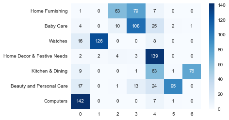

```python
df_cm = pd.DataFrame(conf_mat, index = [label for label in labels_names])
plt.figure()
ax3 = sns.heatmap(df_cm, annot=True, cmap='Blues', fmt='g')
plt.show()
```

## Dimentionality reduction with tSNE on VGG16_features

```python
tsne = manifold.TSNE(n_components=2, perplexity=20,
                     n_iter=2000, init='random', learning_rate='auto')

vgg16_part_trans_tsne = tsne.fit_transform(vgg16_part_trans)
df_VGG_part = pd.DataFrame(vgg16_part_trans_tsne[:,0:2], columns=['tsne1', 'tsne2'])

# vgg16_part_tsne = tsne.fit_transform(VGG16_features) # the ARI isn't any better
# df_VGG_part = pd.DataFrame(vgg16_part_tsne[:,0:2], columns=['tsne1', 'tsne2'])

print(df_VGG_part.shape)
```

```
(1050, 2)
```

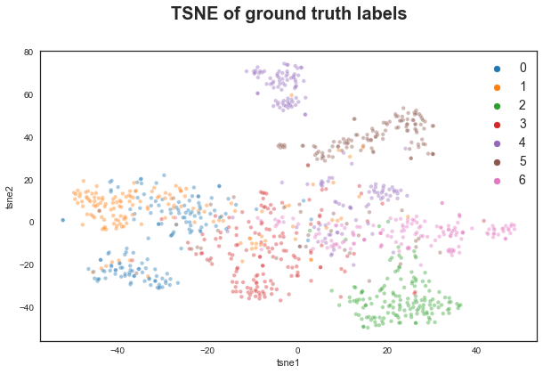

```python
plt.figure(figsize=(10,6))
sns.scatterplot(
    x='tsne1', y='tsne2',
    hue=orig_labels,
    palette=sns.color_palette('tab10', n_colors=7), s=20, alpha=0.4,
    data=df_VGG_part,
    legend='brief')

plt.title('TSNE of ground truth labels', fontsize = 20, pad = 35, fontweight = 'bold')
# plt.xlabel('tsne1', fontsize=16, fontweight = 'bold')
# plt.ylabel('tsne2', fontsize=16, fontweight = 'bold')
plt.legend(prop={'size': 14})

plt.show()
```

```python
kmeans = cluster.KMeans(n_clusters=7)
kmeans.fit(vgg16_part_trans_tsne)

VGG16_part_tsne_labels = kmeans.labels_
df_VGG_part['tsne_labels'] = kmeans.labels_
print(df_VGG_part.shape)
```

```
(1050, 3)
```

```python
conf_mat = metrics.confusion_matrix(orig_labels, VGG16_part_tsne_labels)
print('ARI of KMeans labels', metrics.adjusted_rand_score(orig_labels, VGG16_part_tsne_labels))
print('AMutual Info score of KMeans labels', metrics.adjusted_mutual_info_score(orig_labels, VGG16_part_tsne_labels))
print('Homogeneity score of KMeans labels', metrics.homogeneity_score(orig_labels, VGG16_part_tsne_labels))
print('Completeness score of KMeans labels', metrics.completeness_score(orig_labels, VGG16_part_tsne_labels))
print('Fowlkes Mallows score of KMeans labels', metrics.fowlkes_mallows_score(orig_labels, VGG16_part_tsne_labels))
print('Silhouette score of KMeans labels', metrics.silhouette_score(vgg16_part_trans_tsne, VGG16_part_tsne_labels))
print('Davies-Bouldin index of KMeans labels', metrics.davies_bouldin_score(vgg16_part_trans_tsne, VGG16_part_tsne_labels)) # when use redu_spa, TypeError: A sparse matrix was passed, but dense data is required. Use X.toarray() to convert to a dense numpy array.
print('Calinski-Harabasz score of KMeans labels', metrics.calinski_harabasz_score(vgg16_part_trans_tsne, VGG16_part_tsne_labels)) # when use redu_spa, TypeError: A sparse matrix was passed, but dense data is required. Use X.toarray() to convert to a dense numpy array.
```

```
ARI of KMeans labels 0.45581113718512606
AMutual Info score of KMeans labels 0.5641726313677836
Homogeneity score of KMeans labels 0.5632046674253036
Completeness score of KMeans labels 0.5730615004254648
Fowlkes Mallows score of KMeans labels 0.5357191154119432
Silhouette score of KMeans labels 0.48539364
Davies-Bouldin index of KMeans labels 0.7011811671655109
Calinski-Harabasz score of KMeans labels 1534.4202979274207
```

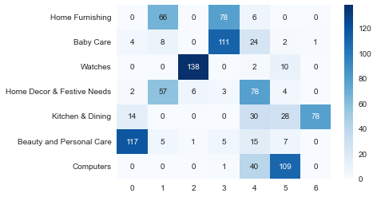

```python
df_cm = pd.DataFrame(conf_mat, index = [label for label in labels_names])
plt.figure()
ax3 = sns.heatmap(df_cm, annot=True, cmap='Blues', fmt='g')
plt.show()
```

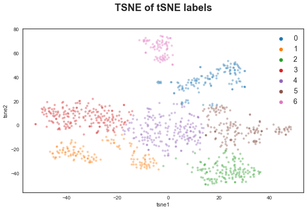

```python
plt.figure(figsize=(10,6))
sns.scatterplot(
    x='tsne1', y='tsne2',
    hue=VGG16_part_tsne_labels,
    palette=sns.color_palette('tab10', n_colors=7), s=20, alpha=0.4,
    data=df_VGG_part,
    legend='brief')

plt.title('TSNE of tSNE labels', fontsize = 20, pad = 35, fontweight = 'bold')
# plt.xlabel('tsne1', fontsize=16, fontweight = 'bold')
# plt.ylabel('tsne2', fontsize=16, fontweight = 'bold')
plt.legend(prop={'size': 14})

plt.show()
```

The result of the image clustering is poorer than that of text treatment.

# Text treatment

## Remove of "rubbish text"

Many descriptions contain "rubbish text", that can't help identify the category of the product. I could identify only: (maybe there are more)

- '- Great Discounts '
- 'Only Genuine Products'
- '30 Day Replacement Guarant'

I identified it during work in "text analysis" section (the one below): creating Text objects and running "concordance", "similar" and "common_contexts" methods with various words. You can see these tests below, after removal of (some of) the rubbish words.

```python
# descri.loc[:, 'description'] = descri.description.apply(lambda x: x.lower())
descri.loc[:, 'description'] = descri.description.str.lower()
```

```python
# descri[descri.description.str.contains('Only Genuine Products', case=False)].index # 564
# descri[descri.description.str.contains('Genuine Products', case=False)].index # not more, also 564
# descri[descri.description.str.contains('Great Discounts', case=False)].index
# descri[descri.description.str.contains('at best prices', case=False)].index
# descri[descri.description.str.contains('Lowest Prices', case=False)].index
# descri[descri.description.str.contains('free shipping', case=False)].index
# descri[descri.description.str.contains('cash on delivery', case=False)].index
# descri[descri.description.str.contains('in India Only at Flipkart.com', case=False)].index
# descri[descri.description.str.contains('Flipkart.com', case=False)].index # 384-226-150 = 8
# descri[descri.description.str.contains('best quality', case=False)].index
# descri[descri.description.str.contains('online', case=False)].index
# descri[descri.description.str.contains('price', case=False)].index
```

```python
# descri.loc[5, 'description']
# descri.loc[35, 'description']
# descri.loc[56, 'description']
# descri.loc[125, 'description']
# descri.loc[5, 'description']
# descri.loc[993, 'description']
# descri.loc[1049, 'description']
```

Meaningless words, specific to this document set, as "price", "buy" etc, can be thrown away with the parameter max_df in vectorizer, be that Count or Tfidf.

```python
empty_phrases = ['great discounts,', 'genuine products', '30 day replacement guarantee', 'cash on delivery'
'free shipping',
'lowest prices,', 'best prices',
'in india only at flipkart.com', 'flipkart.com',
'key features', 'high quiality', 'best quiality',
'promise to deliver best quality products']
for empty_phrase in empty_phrases:
    descri.loc[:, 'description'] = descri.description.str.replace(empty_phrase,' ', regex=False)
```

https://pandas.pydata.org/docs/reference/api/pandas.Series.str.replace.html

Break long words into short tokens. It would be handier to get used to re.sub() instead of replace.

This replacement avoids glueing of several words into one long token that will be removed as a hapax on next steps.

```python
gluey_symbols = ['.', '_', '-', '/', ':', ',']
for symb in gluey_symbols:
    descri.loc[:, 'description'] = descri.description.str.replace(symb,' ', regex=False)
descri.loc[:, 'description'] = descri.description.str.replace('wi fi', 'wifi')
```

## Text analysis after removal of "rubbish text"

```python
total_description = ' '.join(descri.description)
```

```python
regexp = nltk.RegexpTokenizer(r'\w+')
wordpunct = nltk.WordPunctTokenizer() # (pattern='\\w+|[^\\w\\s]+', gaps=False, discard_empty=True, flags=re.UNICODE|re.MULTILINE|re.DOTALL)
```

```python
# total_description = total_description.lower()
test_w = Text(nltk.word_tokenize(total_description))
test_regex = Text(regexp.tokenize(total_description))
test_wp = Text(wordpunct.tokenize(total_description))
print(len(test_w), len(test_regex), len(test_wp))
```

```
79187 76095 79540
```

```python
# test_w.concordance('features') # genuine, India, rs. originally it's Rs which means indian rupies
# # print()
# # test_w.similar('good')
# # test_w.common_contexts(['good', 'your'])
# # test_w.common_contexts(['good', 'ideal'])
# # # test_w.dispersion_plot(['brilliant', 'extra', 'large', 'compact']) # the same for word_tokenize regexp and wordpunct
```

```python
test_w.concordance('abkl') # genuine, India, rs. originally it's Rs which means indian rupies
```

```
Displaying 9 of 9 matches:
 are maintenance free of antiqueshop abkl grn grn grn soft on the skin rope lo
and relaxing warm shower antiqueshop abkl grn grn grn price rs 349 brand new n
 stock specifications of antiqueshop abkl grn grn grn in the box 3 back loofah
d soaps and body wash of antiqueshop abkl pl pnk pnk soft on the skin rope loo
and relaxing warm shower antiqueshop abkl pl pnk pnk price rs 349 brand new ny
 stock specifications of antiqueshop abkl pl pnk pnk in the box 3 back loofah
d soaps and body wash of antiqueshop abkl pl pl pnk soft on the skin rope loop
and relaxing warm shower antiqueshop abkl pl pl pnk price rs 349 brand new nyl
 stock specifications of antiqueshop abkl pl pl pnk in the box 3 back loofah l
```

```python
test_wp.concordance('hookah') # genuine, India, rs. originally it's Rs which means indian rupies
```

```
Displaying 7 of 7 matches:
ivery ! buy arsalan 10 5 inch glass hookah for rs 349 online arsalan 10 5 inch
 349 online arsalan 10 5 inch glass hookah at with free shipping & cash on del
 pegs ' n ' pipes mint double apple hookah flavor for rs 297 online al fakher
 pegs ' n ' pipes mint double apple hookah flavor at with free shipping & cash
bian nights soex cranberry assorted hookah flavor ( 500 g ) price rs 800 an ex
alls ech oly ceramic inside fitting hookah mouth tip ( black ) price rs 699 du
s of ech oly ceramic inside fitting hookah mouth tip ( black ) general brand e
```

```python
test_regex.concordance('loofah')
# # print()
# # test_regex.similar('good')
# # test_regex.common_contexts(['good', 'accessories'])
# # test_regex.common_contexts(['good', 'perfect'])
# # # test_regex.dispersion_plot(['brilliant', 'extra', 'large', 'compact'])
```

```
Displaying 9 of 9 matches:
 nylon body shower bath puff sponge loofah wash reaching where no other scrubb
 abkl grn grn grn in the box 3 back loofah loofah traits material nylon size m
rn grn grn in the box 3 back loofah loofah traits material nylon size medium a
 nylon body shower bath puff sponge loofah wash reaching where no other scrubb
p abkl pl pnk pnk in the box 3 back loofah loofah traits material nylon size m
pl pnk pnk in the box 3 back loofah loofah traits material nylon size medium a
 nylon body shower bath puff sponge loofah wash reaching where no other scrubb
op abkl pl pl pnk in the box 3 back loofah loofah traits material nylon size m
 pl pl pnk in the box 3 back loofah loofah traits material nylon size medium a
```

```python
fdist_w = nltk.FreqDist(test_w)
fdist_regex = nltk.FreqDist(test_regex)
fdist_wp = nltk.FreqDist(test_wp)
```

```python
for x in fdist_w:
    if len(x) == 1:
        print(x, end='\t')

# for x in fdist_regex:
#     if len(x) == 1:
#         print(x, end='\t')

# for x in fdist_wp:
#     if len(x) == 1:
#         print(x, end='\t')
```

```
)	a	(	!	1	&	5	3	2	4	6	#	x	l	g	%	8	0	7	9	*	s	w	t	e	v	•	i	;	b	n	|	’	r	m	?	u	d	c	@	k	h	p	+	�	'	q	[	]	–	“	”	f	…	`
```

```python
for x in fdist_w:
    if len(x) == 2:
        print(x, end='\t')

# for x in fdist_regex:
#     if len(x) == 2:
#         print(x, end='\t')

# for x in fdist_wp:
#     if len(x) == 2:
#         print(x, end='\t')
```

```
of	to	in	rs	on	is	at	cm	it	's	be	or	no	as	by	an	''	ml	do	so	``	12	10	if	15	mm	id	we	19	up	5v	50	18	pc	40	75	9a	16	17	30	60	13	hp	20	14	45	ce	gb	90	ac	go	kg	34	80	me	32	fs	na	he	23	24	11	my	3d	01	48	22	35	tv	36	pl	ft	43	28	29	59	65	25	27	33	85	86	89	06	69	55	21	hz	56	sf	70	95	pk	re	uv	tr	us	co	fb	58	…
```

```python
# for x in fdist_w:
#     if len(x) == 3:
#         print(x, end='\t')

# for x in fdist_regex:
#     if len(x) == 3:
#         print(x, end='\t')

# for x in fdist_wp:
#     if len(x) == 3:
#         print(x, end='\t')
```

Tokens with 2 symbols have some meaningful words, as ml, rs (Indian Rupies), go, kg, cm, tv, ft, hz, (wi, fi), cd, mm, oz.

Tokens with 1 or 2 letters can be removed. Tokens with 3 letters can not. They have some meaningful words, like "mug", "car", "boy", "dvd" or "gsm".

```python
test_w = Text([tok for tok in test_w if len(tok) > 2])
test_regex = Text([tok for tok in test_regex if len(tok) > 2])
test_wp = Text([tok for tok in test_wp if len(tok) > 2])
```

```python
test_w = Text([tok for tok in test_w if tok.isalpha()])
test_regex = Text([tok for tok in test_regex if tok.isalpha()])
test_wp = Text([tok for tok in test_wp if tok.isalpha()])
```

```python
vocab_w = sorted(set(test_w))
# print(vocab_w[:9])
print(len(vocab_w))

vocab_regex = sorted(set(test_regex))
# print(vocab_regex[:9])
print(len(vocab_regex))

vocab_wp = sorted(set(test_wp))
# print(vocab_wp[:9])
print(len(vocab_wp))
```

```
4866
4876
4876
```

```python
print(set(test_wp).difference(set(test_w)))
print(set(test_regex).difference(set(test_w)))
# print(set(test_wp).difference(set(test_regex))) # empty
# print(set(test_w).difference(set(test_regex))) # empty
# print(set(test_regex).difference(set(test_wp))) # empty
# print(set(test_w).difference(set(test_wp))) # empty
```

```
{'won', 'pipes', 'repouss', 'cor', 'pegs', 'techone', 'qur', 'apollo', 'signer', 'thnkss'}
{'won', 'pipes', 'repouss', 'cor', 'pegs', 'techone', 'qur', 'apollo', 'signer', 'thnkss'}
```

Tokens which are not digits (or are not words) can be removed.

```python
# lexical diversity is vocab size / text size: close to 0 is repetitive vocab, close to 1 is diverse vocab
print(len(set(test_w)) / len(test_w))
print(len(set(test_regex)) / len(test_regex))
print(len(set(test_wp)) / len(test_wp))
```

```
0.08262301762488539
0.08271556769410847
0.08271556769410847
```

```python
fdist_w = nltk.FreqDist(test_w)
fdist_regex = nltk.FreqDist(test_regex)
fdist_wp = nltk.FreqDist(test_wp)
```

```python
print(fdist_w.most_common(8)) # after that, go some meaningful words , then again meaningless
print(fdist_regex.most_common(8)) # after that, go some meaningful words , then again meaningless
print(fdist_wp.most_common(50)) # after that, go some meaningful words , then again meaningless
```

```
[('for', 1447), ('the', 1369), ('and', 1332), ('with', 843), ('only', 756), ('your', 656), ('free', 618), ('buy', 581)]
[('for', 1447), ('the', 1369), ('and', 1332), ('with', 843), ('only', 756), ('your', 656), ('free', 618), ('buy', 581)]
[('for', 1447), ('the', 1369), ('and', 1332), ('with', 843), ('only', 756), ('your', 656), ('free', 618), ('buy', 581), ('delivery', 567), ('shipping', 564), ('cash', 564), ('this', 444), ('online', 396), ('from', 382), ('specifications', 371), ('you', 360), ('price', 352), ('watch', 330), ('color',…
```

```python
print(fdist_w['good']) # on the early stages of treatment the results were different for different tokenizers
# print(fdist_regex['good']) # after punctuation symbols removed, they are the same
# print(fdist_wp['good'])
```

```
40
```

```python
# test_w.collocations()  # frequent bigrams
# test_regex.collocations(10)  # the lists of bigrams were different on early stages of treatment
test_wp.collocations(50) # after treatment they became identical
```

```
shipping cash; cash delivery; free shipping; sales package; analog
watch; baby girl; number contents; contents sales; delivery buy;
general brand; combo set; model name; baby boy; ceramic mug; package
pack; stainless steel; microwave safe; porcelain crafting; stays
permanent; style code; crafting ensuring; loved ones; print shapes;
high quality; thrilling yet; exclusive creation; fabric cotton; water
resistant; mouse pad; pizza cutter; fresh start; years come; creation
rockmantra; yet fresh; give thrilling; fabric care; day exclusive; box
number; covered warranty; general details; box sales; occasion casual;
laptop skin; features porcelain; model number; design stays; may vary;
pick gift; perfect pick; making perfect
```

It would be useful to remove meaningless collocations, like "key features" or "high quality".

Upd: I already did it in the section above.

```python
long_words_w = [w for w in vocab_w if len(w) == 14]
# long_words_regex = [w for w in vocab_regex if len(w) == 14]
# long_words_wp = [w for w in vocab_wp if len(w) == 14]
print(sorted(long_words_w))
# print(sorted(long_words_regex))
# print(sorted(long_words_wp))
```

```
['authentication', 'breathlessness', 'brilliantcolor', 'certifications', 'characteristic', 'classification', 'disintegrating', 'electrotherapy', 'furnishingland', 'interiordesign', 'malfunctioning', 'moisturization', 'multifunctions', 'pscychological', 'rajasthanikart', 'responsibility', 'scientific…
```

for regex and wp tokenizers this list is the same

Notice "brilliantcolor", "furnishingland", "interiordesign", "multifunctions". These are invented words or typos. "rajasthanikart" may be a name of a card specific to India.

```python
# sorted(w for w in vocab_w if w.endswith('ness'))
# sorted(w for w in vocab_regex if len(w) > 6 and fdist_regex[w] > 7)
# sorted(term for term in vocab_w if 'rs' in term)
# sorted(item for item in vocab_w if item.istitle())
# sorted(wd for wd in vocab_w if wd.istitle() and len(wd) > 10)
# sorted(w for w in vocab4 if not w.islower())
# sorted(w for w in vocab_w if '.' in w and 'rs' in w)
# sorted(item for item in vocab_w if item.isdigit())
```

These are usefull collections. We can take the vocabulary and delete the digits. Or take only the tokens composed of letters, as I did above.

```python
print('number of words', len(test_w), len(test_regex), len(test_wp))
print('vocab size', len(set(test_w)), len(set(test_regex)), len(set(test_wp)))

# print(len(set(word.lower() for word in test_w))) # no need if I did .lower before
# print(len(set(word.lower() for word in test_regex))) # no need if I did .lower before
# print(len(set(word.lower() for word in test_wp))) # no need if I did .lower before
```

```
number of words 58894 58949 58949
vocab size 4866 4876 4876
```

In these conditions of pre-treatment, Wordpunct Tokenizer do the same thing as Regex tokenizer with chosen regular expression. So for next tests I will keep only simple word tokenizer and wordpunct tokenizer.

# Prepare dataset

## Tokenization, keep letters only and long words only, remove stopwords

```python
my_stopwords = stopwords.words('english')

'''Meaningless words, specific to this documents set, as "price", "buy" etc, can be thrown away
with the parameter max_df in vectorizer, be that Count or Tfidf.'''


# my_stopwords.extend(['prices', 'price',
# 'delivering', 'delivered', 'delivery', 'deliver',
# 'products', 'product', 'customers', 'customer', 'shopping', 'shops', 'shop',
#                      'sales', 'sale',
# #                      'model', 'details'
# #                     'specifications', 'general', 'features',
#                         'online', 'quality', 'buy', 'only'])
print(my_stopwords)
```

```
['i', 'me', 'my', 'myself', 'we', 'our', 'ours', 'ourselves', 'you', "you're", "you've", "you'll", "you'd", 'your', 'yours', 'yourself', 'yourselves', 'he', 'him', 'his', 'himself', 'she', "she's", 'her', 'hers', 'herself', 'it', "it's", 'its', 'itself', 'they', 'them', 'their', 'theirs', 'themselve…
```

```python
def letters_only (my_series):
    return my_series.map(lambda x: [word for word in x if word.isalpha()])

def long_only (my_series):
    return my_series.map(lambda x: [word for word in x if len(word) > 2])

def no_stopwords (my_series):
    return my_series.map(lambda x: [word for word in x if word not in my_stopwords])

def letters_long_stopwords (my_series):
    return my_series.map(lambda x: [word for word in x if word.isalpha() and len(word) > 2 and word not in my_stopwords])

def letters_long (my_series):
    return my_series.map(lambda x: [word for word in x if word.isalpha() and len(word) > 2])
```

```python
descri['token'] = descri.description.map(lambda x: nltk.word_tokenize(x))
# descri['wp_token'] = descri.description.apply(lambda x: wordpunct.tokenize(x))
# descri['regex_token'] = descri.description.apply(lambda x: regexp.tokenize(x))
```

(descri.token == descri.wp_token).all() # output is False after tokenization.

```python
'''stopwords can be thrown away with parameter "stopwords" of a vectorizer, be that Count or Tfidf"'''
# descri['token'] = letters_only(descri.token)
# descri['wp_token'] = letters_only(descri.wp_token)

# descri['token'] = long_only(descri.token)
# descri['wp_token'] = long_only(descri.wp_token)

# descri['token'] = no_stopwords(descri.token)
# descri['wp_token'] = no_stopwords(descri.wp_token)

# descri['token'] = letters_long_stopwords(descri.token)
# descri['wp_token'] = letters_long_stopwords(descri.wp_token)

# descri['token'] = letters_long(descri.token)
# descri['wp_token'] = letters_long(descri.wp_token)
```

```
'stopwords can be thrown away with parameter "stopwords" of a vectorizer, be that Count or Tfidf"'
```

(descri.token == descri.wp_token).all() # output is True after remove of short words, non-letter words and stopwords.

The result for Rexex Tokenizer is the same: series are different after tokenization, but identical after removal of non-letter words, short words and stopwords

(just to remind, Regex and Wordpunkt gave identical results already after tokenization).

So, no need to use standard tokenizer and Wordpunct Tokenizer: they give identical results. for the future I will keep only standard NLTK tokenizer.

## Stemming and lemmatization

I will try 3 stemmers: Porter Stemmer, Lancaster Stemmer (which is harcher than Porter) and WordNet Lemmatizer (the last one needs Download the WordNet corpora from NLTK downloader). The stemmers and lemmatizers are taken from https://www.datacamp.com/community/tutorials/stemming-lemmatization-python

And the columns xxx_token stay non-stemmed un non-lemmatized. I want to compare the results with different stemmers/lemmatizers and in their absence.

```python
stem_porter = PorterStemmer()
stem_lancaster=LancasterStemmer()
lemmatizer = WordNetLemmatizer()
lemmatizer_multi = WNL()
```

Porter Stemmer

```python
descri['porter'] = descri.token.map(lambda x: [stem_porter.stem(word) for word in x])
# descri['wp_porter'] = descri.wp_token.map(lambda x: [stem_porter.stem(word) for word in x])
# descri['regex_porter'] = descri.regex_token.map(lambda x: [stem_porter.stem(word) for word in x])
```

Lancaster Stemmer

```python
descri['lancaster'] = descri.token.map(lambda x: [stem_lancaster.stem(word) for word in x])
# descri['wp_lancaster'] = descri.wp_token.map(lambda x: [stem_lancaster.stem(word) for word in x])
# descri['regex_lancaster'] = descri.regex_token.map(lambda x: [stem_lancaster.stem(word) for word in x])
```

WordNet Lemmatizer

```python
descri['lemma'] = descri.token.map(lambda x: [lemmatizer.lemmatize(word, pos='v') for word in x]) # part of speech = verb?
# descri['wp_lemma'] = descri.wp_token.map(lambda x: [w_lemmatizer.lemmatize(word, pos='v') for word in x]) # part of speech = verb?
# descri['regex_lemma'] = descri.regex_token.map(lambda x: [w_lemmatizer.lemmatize(word, pos='v') for word in x]) # part of speech = verb?

# if problems with lemmatization to the needed POS, see
# https://stackoverflow.com/questions/15586721/wordnet-lemmatization-and-pos-tagging-in-python
```

WordNet lemmatizer with Part-Of-Speech distinction. Recognizes Noun, Verb, Adjective, Adverb (but not Satellite Adjectives)

```python
tag_map = defaultdict(lambda : wordnet.NOUN)
tag_map['J'] = wordnet.ADJ
tag_map['V'] = wordnet.VERB
tag_map['R'] = wordnet.ADV
print(tag_map)
descri['lemma_pos'] = descri.token.map(lambda x: [lemmatizer_multi.lemmatize(token, tag_map[tag[0]]) for token, tag in nltk.pos_tag(x)])
print(tag_map)
```

```
defaultdict(<function <lambda> at 0x000002670925A940>, {'J': 'a', 'V': 'v', 'R': 'r'})
defaultdict(<function <lambda> at 0x000002670925A940>, {'J': 'a', 'V': 'v', 'R': 'r', 'I': 'n', 'N': 'n', '(': 'n', 'C': 'n', ')': 'n', '$': 'n', 'D': 'n', 'P': 'n', 'T': 'n', 'W': 'n', 'M': 'n', '.': 'n', "'": 'n', 'U': 'n', 'F': 'n', '`': 'n', ':': 'n', 'S': 'n', 'E': 'n', '#': 'n'})
```

```python
for stem_lemma1 in ['token', 'porter', 'lancaster', 'lemma', 'lemma_pos']:
    for stem_lemma2 in ['token', 'porter', 'lancaster', 'lemma', 'lemma_pos']:
        print((descri[stem_lemma1] == descri[stem_lemma2]).all(), end='\t')
    print()
```

```
True	False	False	False	False
False	True	False	False	False
False	False	True	False	False
False	False	False	True	False
False	False	False	False	True
```

Different stemmers/lemmatizers, all give non-identical results, unlike different tokenizers. So, it makes sense to keep all the stemmers and lemmatizers, but not the 3 different tokenizers that I tested.

## Delete the words that are too rare

"If the frequent words don't help us, how about the words that occur once only, the so-called hapaxes? View them by typing fdist1.hapaxes(). This list contains lexicographer, cetological, contraband, expostulations, and about 9,000 others. It seems that there are too many rare words, and without seeing the context we probably can't guess what half of the hapaxes mean in any case! Since neither frequent nor infrequent words help, we need to try something else."

In fact, function hapaxes shows the words that occur only once. To remove it, I have to check every word in database if it is in the list of hapaxes. And keep only those which are not in that list.

I can also remove words occuring less than given number of times. See function "remove hapaxes".

```python
def remove_hapaxes_and_too_frequent (my_series):
    my_series_total_d = ' '.join(my_series.map(lambda x: ' '.join(x)))
    my_series_total_d = my_series_total_d.split()
    my_series_total_d = Text(my_series_total_d)
    my_series_fdist = nltk.FreqDist(my_series_total_d)
# this is the same as set min_df=2 in vectorizer, Count or TfIdf
    my_series_hapax = my_series_fdist.hapaxes() # shall I better remove words that occur less than 3 times ? less than 5 times?
#  this is the same as set min_df=3 in vectorizer, Count or TfIdf
#     my_series_lessthan = [w for w in set(my_series_total_d) if my_series_fdist[w] < 3]
    my_series_between = [w for w in set(my_series_total_d) if my_series_fdist[w] < 3 and my_series_fdist[w] < 333]
    print('words number:', len(my_series_total_d), end= '')
    print('; vocab length:', len(my_series_fdist), end= '')
    print('; hapax number:', len(my_series_hapax), end= '')
#     print('; new vocab len:', len(my_series_fdist) - len(my_series_hapax))
#     print('; new vocab len:', len(my_series_lessthan), ';')
    print('; new vocab len:', len(my_series_between), ';')
#     return my_series.map(lambda x: [word for word in x if word not in my_series_hapax])
#     return my_series.map(lambda x: [word for word in x if word not in my_series_lessthan])
    return my_series.map(lambda x: [word for word in x if word not in my_series_between])
```

```python
'''The function "remove_hapaxes_and_too_frequent" is eventually not needed,
as min_df parameter does the same in vectorizer, be that Count of Tfidf.'''

# descri['token'] = remove_hapaxes_and_too_frequent(descri.token)
# # descri['wp_token'] = remove_hapaxes_and_too_frequent(descri.wp_token)
# descri['porter'] = remove_hapaxes_and_too_frequent(descri.porter)
# # descri['wp_porter'] = remove_hapaxes_and_too_frequent(descri.wp_porter)
# descri['lancaster'] = remove_hapaxes_and_too_frequent(descri.lancaster)
# # descri['wp_lancaster'] = remove_hapaxes_and_too_frequent(descri.wp_lancaster)
# descri['lemma'] = remove_hapaxes_and_too_frequent(descri.lemma)
# # descri['wp_lemma'] = remove_hapaxes_and_too_frequent(descri.wp_lemma)
# descri['lemma_pos'] = remove_hapaxes_and_too_frequent(descri.lemma_pos)
# # descri['wp_lemma_pos'] = remove_hapaxes_and_too_frequent(descri.wp_lemma_pos)
```

```
'The function "remove_hapaxes_and_too_frequent" is eventually not needed, \nas min_df parameter does the same in vectorizer, be that Count of Tfidf.'
```

If 'remove_hapaxes" function applied, the results would be:

- words number: 46077; vocab length: 4777; hapax number: 1407; new vocab len: 3370
- words number: 46077; vocab length: 3801; hapax number: 1010; new vocab len: 2791
- words number: 46077; vocab length: 3416; hapax number: 848; new vocab len: 2568
- words number: 46077; vocab length: 4189; hapax number: 1183; new vocab len: 3006
- words number: 46077; vocab length: 4165; hapax number: 1193; new vocab len: 2972

# Text Pipelines: dimensionality reduction, clustering, evaluation, visualization

Dimentionality reduction can be done by two methods: either choose the greedy vectorizer that takes only P most frequent words with parameter max_features of the vectorizer; or takes full vocabulary, re-orient the axes of vocab space using PCA, takes the components (not the words!), in other words the coordinates along new axes, where chosen axes are just the direction of the biggest variance of the dots cloud.

```python
def vectorize_pdseries (myseries, myvectorizer):
#     myse_array = descri[myseries].str.join(' ').values # input string names of a series
    myse_array = myseries.str.join(' ').values # input a series, like df.pdseries
    myse_vectors = myvectorizer.fit_transform(myse_array)
#     print(type(myse_vectors), myse_vectors.shape)
#     return myse_vectors, myvectorizer.get_feature_names()
#     return myse_vectors.toarray(), myvectorizer.get_feature_names()
    return myse_vectors, myse_vectors.toarray()
```

```python
metric_comparison = []
```

## Dimensionality reduction made with greedy vectorizers

CountVectorizer is a part of TF-IDF vectorizer. Tfidf Vectorizer is "Equivalent to CountVectorizer followed by TfidfTransformer". https://scikit-learn.org/stable/modules/generated/sklearn.feature_extraction.text.TfidfVectorizer.html

I use the guide from https://towardsdatascience.com/getting-started-with-text-vectorization-2f2efbec6685

```python
# binary_vectorizer = TfidfVectorizer(
#     binary=True, norm=False,
#     use_idf=False, smooth_idf=False,
#     lowercase=False, # stop_words='english', # don't need to apply these params
# #     min_df=2, max_df=0.7, max_features=250, ngram_range=(1,1) # default values
# )

# stably gives worse results than other configurations of vectorizer, so it's taken out of comparison
```

```python
# bag_of_words_vectorizer = TfidfVectorizer(
#     binary=False, norm=None,  # if vectorizer works badly, change norm None ->False as in binary_vecto
#     use_idf=False, smooth_idf=False,
#     lowercase=False, # stop_words='english', # don't need to apply these params
# #     min_df=2, max_df=0.7, max_features=250, ngram_range=(1,1) # default values
# )

# # as I understood, in this configuration of parameters TfidfVectorizer is equivalent to CountVectorizer
# # the experiment on a tiny doc set that I generated confirmed it. So I just use CountVectorizer instead
# # just note that TfidfVectorizer always return floats, and here too, while CountVectorizer returns integers
```

```python
greedy_count = CountVectorizer(min_df=2, max_df=0.29, max_features=400)
```

```python
greedy_tf  = TfidfVectorizer(
    binary=False, norm='l1',
    use_idf=False, smooth_idf=False,
    lowercase=False, # stop_words='english', # don't need to apply these params
    min_df=2, max_df=0.29, max_features=400, ngram_range=(1,1) # default values
)

# this one is different from CountVecto in a span of 1 doc and also between the docs. default config of TfidfVecto
```

```python
greedy_tf_idf = TfidfVectorizer(
    binary=False, norm='l2',
    use_idf=True, smooth_idf=True,
    lowercase=False, # stop_words='english', # don't need to apply these params
    min_df=2, max_df=0.29, max_features=400, ngram_range=(1,1) # default values
)

# this one is different from CountVecto in a span of 1 doc and also between the docs. default config of TfidfVecto
```

```python
greedy_tf_idf_bigrams = TfidfVectorizer(
    binary=False, norm='l2',
    use_idf=True, smooth_idf=True,
    lowercase=False, # stop_words='english', # don't need to apply these params
    min_df=2, max_df=0.29, max_features=400, ngram_range=(1,2) # default values
)

# this one is different from CountVecto in a span of 1 doc and also between the docs. default config of TfidfVecto
```

```python
# redu_count_spa, redu_count_arr = vectorize_pdseries(greedy_count_vectorizer, descri.lemma_pos)
# redu_tf_spa, redu_tf_arr = vectorize_pdseries(greedy_tf, descri.lemma_pos)
# redu_tfidf_spa, redu_arr = vectorize_pdseries(greedy_tf_idf, descri.lemma_pos)
```

#### Metrics:

Given the knowledge of the ground truth class assignments _labels*true*, Adjusted Rand index is a function that measures the similarity of the two assignments. A **higher Adjusted Rand index** relates to a model with higher similarity.

If the ground truth labels are not known, Silhouette Coefficient is OK. A **higher Silhouette Coefficient** score relates to a model with better defined clusters.

If the ground truth labels are not known, the Calinski-Harabasz index is OK. A **higher Calinski-Harabasz score** relates to a model with better defined clusters.

If the ground truth labels are not known, Davies-Bouldin index is OK. A **lower Davies-Bouldin index** relates to a model with better separation between the clusters

```python
def greedy_vectorizer_pipeline(name_series, name_vectorizer, myn_clusters=7, comparison=True, pictures=False):
    myseries = descri[name_series]
    myvectorizer = eval(name_vectorizer)
    redu_spa, redu_arr = vectorize_pdseries(myseries, myvectorizer)
    print(redu_arr.shape, end='\t')

# #     if pictures:
# #         # original labels tSNEvis: with yellowbrick library
# #         tsne_vis_orig = TSNEVisualizer(decompose=None, perplexity=20, colors=color_palette('tab20'))
# #         # decompose='svd',  decompose='pca', colors=[plt.cm.Set3(i) for i in range(12)]
# #         # when X = redu_spa and decompose='pca', TypeError: PCA does not support sparse input. Use TruncatedSVD
# #         tsne_vis_orig.fit(redu_spa, orig_labels_names) # redu_spa for SVD or None decomposition method; redu_arr for PCA or None decomposition method
# #         tsne_vis_orig.show()

    if pictures:
        # original labels tSNEvis: with tSNE manifold and seaborn graph
        orig_tsne = manifold.TSNE(n_components=2, init='random', perplexity=20, learning_rate='auto') # init='pca' requires redu_arr
        X_trans = orig_tsne.fit_transform(redu_spa)  # init='pca' requires redu_arr
        X_df = pd.DataFrame(X_trans, columns=['dim1', 'dim2'])
        plt.figure()
        ax1 = scatterplot(x='dim1', y='dim2', data=X_df, hue=orig_labels_names, palette='tab10', alpha=0.5)


    # clustering with KMeans on text array
    myclust = cluster.KMeans(n_clusters=myn_clusters)
    myclust.fit(redu_spa) # also works with redu_arr, with the same result
    kmeans_labels = myclust.labels_
    if pictures:
        print('Cluster sizes \n{}'.format(pd.Series(kmeans_labels).value_counts())) # someties can be more than a half of all documents in 1 cluster

# #     # clustering with GaussianMixture on text array
#     mygaussian = GaussianMixture(n_components=myn_clusters)
#     mygaussian.fit(redu_arr)
# #     gaussian_labels = gaussian.predict(redu_spa) if tests show that Gaussian is better than KMeans
#     kmeans_labels = mygaussian.predict(redu_arr)
#     if pictures:
#         print('Cluster sizes \n{}'.format(pd.Series(kmeans_labels).value_counts())) # someties can be more than a half of all documents in 1 cluster



    # Metrics
    conf_mat = metrics.confusion_matrix(orig_labels, kmeans_labels)
    if comparison:
        metric_comparison.append(['greedy', 'notSNE', name_vectorizer, name_series,
               round(metrics.adjusted_rand_score(orig_labels, kmeans_labels), 3),
               round(metrics.adjusted_mutual_info_score(orig_labels, kmeans_labels), 3),
               round(metrics.homogeneity_score(orig_labels, kmeans_labels), 3),
               round(metrics.completeness_score(orig_labels, kmeans_labels), 3),
               round(metrics.fowlkes_mallows_score(orig_labels, kmeans_labels), 3),
               round(metrics.silhouette_score(redu_spa, kmeans_labels), 3),
               round(metrics.davies_bouldin_score(redu_arr, kmeans_labels), 3),  # TypeError: A sparse matrix was passed, but dense data is required. Use X.toarray() to convert to a dense numpy array.
               round(metrics.calinski_harabasz_score(redu_arr, kmeans_labels), 3)]) # TypeError: A sparse matrix was passed, but dense data is required. Use X.toarray() to convert to a dense numpy array.


    if pictures:
        print('ARI of KMeans labels', metrics.adjusted_rand_score(orig_labels, kmeans_labels))
        print('AMutual Info score of KMeans labels', metrics.adjusted_mutual_info_score(orig_labels, kmeans_labels))
        print('Homogeneity score of KMeans labels', metrics.homogeneity_score(orig_labels, kmeans_labels))
        print('Completeness score of KMeans labels', metrics.completeness_score(orig_labels, kmeans_labels))
        print('Fowlkes Mallows score of KMeans labels', metrics.fowlkes_mallows_score(orig_labels, kmeans_labels))
        print('Silhouette score of KMeans labels', metrics.silhouette_score(redu_spa, kmeans_labels))
        print('Davies-Bouldin index of KMeans labels', metrics.davies_bouldin_score(redu_arr, kmeans_labels)) # when use redu_spa, TypeError: A sparse matrix was passed, but dense data is required. Use X.toarray() to convert to a dense numpy array.
        print('Calinski-Harabasz score of KMeans labels', metrics.calinski_harabasz_score(redu_arr, kmeans_labels)) # when use redu_spa, TypeError: A sparse matrix was passed, but dense data is required. Use X.toarray() to convert to a dense numpy array.
# #       print(conf_mat)
# #       print(metrics.classification_report(orig_labels, my_labels))


# #     # KMeans labels tSNEvis: with yellowbrick library
# #     tsne_vis_kmeans = TSNEVisualizer(decompose=None, perplexity=20, colors=color_palette('tab20'))
# #     # decompose='svd',  decompose='pca', colors=[plt.cm.Set3(i) for i in range(12)]
# #     tsne_vis_kmeans.fit(redu_spa, my_labels) # redu_spa for SVD or None decomposition method; redu_arr # for use PCA or None decomposition method
# #     tsne_vis_kmeans.show()

    # KMeans labels tSNEvis: with tSNE manifold and seaborn graph
    myclust_tsne = manifold.TSNE(n_components=2, init='random', perplexity=20, learning_rate='auto') # init='pca' requires redu_arr
#     method='exact'
    X_trans = myclust_tsne.fit_transform(redu_spa) # init='pca' requires redu_arr
    X_df = pd.DataFrame(X_trans, columns=['dim1', 'dim2'])
    if pictures:
        plt.figure(figsize=(10,6))
        ax2 = scatterplot(x='dim1', y='dim2', data=X_df, hue=kmeans_labels, palette='tab10', alpha=0.5)
        plt.title('tSNEvis of KMeans clusters') #, fontsize = 30, pad = 35, fontweight = 'bold')
        plt.show()


    # draw a confusion matrix
    if pictures:
        df_cm = pd.DataFrame(conf_mat, index = [label for label in labels_names])
        plt.figure()
        ax3 = sns.heatmap(df_cm, annot=True, cmap='Blues', fmt='g')
        plt.show()


    # clustering with KMeans on tSNE projection
    cls_from_tsne = cluster.KMeans(n_clusters=7)
    cls_from_tsne.fit(X_trans)
    tsne_labels = cls_from_tsne.labels_
    if pictures:
        print('Cluster sizes \n{}'.format(pd.Series(tsne_labels).value_counts())) # someties can be more than a half of all documents in 1 cluster


#     #     # clustering with GaussianMixture on text array
#     gaussian_from_tsne = GaussianMixture(n_components=myn_clusters)
#     gaussian_from_tsne.fit(X_trans)
# #     gaussian_tsne_labels = gaussian.predict(redu_spa) if tests show that Gaussian is better than KMeans
#     tsne_labels = gaussian_from_tsne.predict(X_trans)
#     if pictures:
#         print('Cluster sizes \n{}'.format(pd.Series(tsne_labels).value_counts())) # someties can be more than a half of all documents in 1 cluster


    # Metrics
    conf_mat = metrics.confusion_matrix(orig_labels, tsne_labels)
    if comparison:
        metric_comparison.append(['greedy', 'tSNE', name_vectorizer, name_series,
               round(metrics.adjusted_rand_score(orig_labels, tsne_labels), 3),
               round(metrics.adjusted_mutual_info_score(orig_labels, tsne_labels), 3),
               round(metrics.homogeneity_score(orig_labels, tsne_labels), 3),
               round(metrics.completeness_score(orig_labels, tsne_labels), 3),
               round(metrics.fowlkes_mallows_score(orig_labels, tsne_labels), 3),
               round(metrics.silhouette_score(redu_spa, tsne_labels), 3),
               round(metrics.davies_bouldin_score(redu_arr, tsne_labels), 3),  # TypeError: A sparse matrix was passed, but dense data is required. Use X.toarray() to convert to a dense numpy array.
               round(metrics.calinski_harabasz_score(redu_arr, tsne_labels), 3)]) # TypeError: A sparse matrix was passed, but dense data is required. Use X.toarray() to convert to a dense numpy array.
    if pictures:
        print('ARI of labels from tSNE', metrics.adjusted_rand_score(orig_labels, tsne_labels))
        print('AMutual Info score of labels from tSNE', metrics.adjusted_mutual_info_score(orig_labels, tsne_labels))
        print('Homogeneity score of labels from tSNE', metrics.homogeneity_score(orig_labels, tsne_labels))
        print('Completeness score of labels from tSNE', metrics.completeness_score(orig_labels, tsne_labels))
        print('Fowlkes Mallows score of labels from tSNE', metrics.fowlkes_mallows_score(orig_labels, tsne_labels))
        print('Silhouette score of labels from tSNE', metrics.silhouette_score(redu_spa, tsne_labels))
        print('Davies-Bouldin index of labels from tSNE', metrics.davies_bouldin_score(redu_arr, tsne_labels)) # when use redu_spa, TypeError: A sparse matrix was passed, but dense data is required. Use X.toarray() to convert to a dense numpy array.
        print('Calinski-Harabasz score of labels from tSNE', metrics.calinski_harabasz_score(redu_arr, tsne_labels)) # when use redu_spa, TypeError: A sparse matrix was passed, but dense data is required. Use X.toarray() to convert to a dense numpy array.
# #       print(conf_mat)
# #       print(metrics.classification_report(orig_labels, my_labels))


#   tSNEvis of clusters BASED ON tSNE PROJECTION
    if pictures:
        plt.figure(figsize=(10,6))
        ax4 = sns.scatterplot(x='dim1', y='dim2', data=X_df, hue=tsne_labels, palette='tab10', alpha=0.5)
    #     hue='cl_lab'
        plt.title('TSNEvis of clusters based on tSNE') #, fontsize = 30, pad = 35, fontweight = 'bold')
    #     plt.xlabel('tsne1', fontsize = 26, fontweight = 'bold')
    #     plt.ylabel('tsne2', fontsize = 26, fontweight = 'bold')
    #     plt.legend(prop={'size': 14})
        plt.show()

    # draw a confusion matrix
    if pictures:
        df_cm = pd.DataFrame(conf_mat, index = [label for label in labels_names])
        plt.figure()
        ax3 = sns.heatmap(df_cm, annot=True, cmap='Blues', fmt='g')
        plt.show()
    return None
```

```python
# for vectoriz in ['greedy_count_vectorizer', 'greedy_tf', 'greedy_tf_idf', 'greedy_tf_idf_bigrams']:
for vectoriz in ['greedy_count', 'greedy_tf', 'greedy_tf_idf']: # bigrams isn't in the list of champions, not for any metric
#     for stem_lemma in descri.columns[8:]:
    for stem_lemma in ['token', 'porter', 'lancaster', 'lemma', 'lemma_pos']:
        greedy_vectorizer_pipeline(stem_lemma, vectoriz)
# print(descri.columns[6:])
```

```
(1050, 400)	(1050, 400)	(1050, 400)	(1050, 400)	(1050, 400)	(1050, 400)	(1050, 400)	(1050, 400)	(1050, 400)	(1050, 400)	(1050, 400)	(1050, 400)	(1050, 400)	(1050, 400)	(1050, 400)
```

#### Metrics:

Given the knowledge of the ground truth class assignments _labels*true*, Adjusted Rand index is a function that measures the similarity of the two assignments. A **higher Adjusted Rand index** relates to a model with higher similarity.

Same for other ground truth demanding scores: **higher value is better.**

If the ground truth labels are not known, Silhouette Coefficient is OK. A **higher Silhouette Coefficient** score relates to a model with better defined clusters.

If the ground truth labels are not known, Davies-Bouldin index is OK. A **lower Davies-Bouldin index** relates to a model with better separation between the clusters

If the ground truth labels are not known, the Calinski-Harabasz index is OK. A **higher Calinski-Harabasz score** relates to a model with better defined clusters.

```python
rating_greedy = pd.DataFrame(metric_comparison, columns=['Reduction', 'Projection', 'Vectorizer', 'StemLem',
        'ARI', 'AMII', 'Homo', 'Comple', 'Fowlkes', 'Silho', 'Bouldin', 'Harabasz'])

rating_greedy.Bouldin = rating_greedy.Bouldin * -1
```

```python
for metric in rating_greedy.columns[4:]:
    print(metric, end=' ')
    display(rating_greedy.sort_values(by=metric, ascending=False).head(2))
```

```
ARI
```

|  | Reduction | Projection | Vectorizer | StemLem | ARI | AMII | Homo | Comple | Fowlkes | Silho | Bouldin | Harabasz |
| --- | --- | --- | --- | --- | --- | --- | --- | --- | --- | --- | --- | --- |
| 29 | greedy | tSNE | greedy_tf_idf | lemma_pos | 0.570 | 0.610 | 0.610 | 0.617 | 0.633 | 0.097 | -3.621 | 34.980 |
| 23 | greedy | tSNE | greedy_tf_idf | porter | 0.468 | 0.579 | 0.575 | 0.590 | 0.548 | 0.100 | -3.889 | 35.874 |

```
AMII
```

|  | Reduction | Projection | Vectorizer | StemLem | ARI | AMII | Homo | Comple | Fowlkes | Silho | Bouldin | Harabasz |
| --- | --- | --- | --- | --- | --- | --- | --- | --- | --- | --- | --- | --- |
| 29 | greedy | tSNE | greedy_tf_idf | lemma_pos | 0.570 | 0.610 | 0.610 | 0.617 | 0.633 | 0.097 | -3.621 | 34.980 |
| 23 | greedy | tSNE | greedy_tf_idf | porter | 0.468 | 0.579 | 0.575 | 0.590 | 0.548 | 0.100 | -3.889 | 35.874 |

```
Homo
```

|  | Reduction | Projection | Vectorizer | StemLem | ARI | AMII | Homo | Comple | Fowlkes | Silho | Bouldin | Harabasz |
| --- | --- | --- | --- | --- | --- | --- | --- | --- | --- | --- | --- | --- |
| 29 | greedy | tSNE | greedy_tf_idf | lemma_pos | 0.570 | 0.610 | 0.610 | 0.617 | 0.633 | 0.097 | -3.621 | 34.980 |
| 23 | greedy | tSNE | greedy_tf_idf | porter | 0.468 | 0.579 | 0.575 | 0.590 | 0.548 | 0.100 | -3.889 | 35.874 |

```
Comple
```

|  | Reduction | Projection | Vectorizer | StemLem | ARI | AMII | Homo | Comple | Fowlkes | Silho | Bouldin | Harabasz |
| --- | --- | --- | --- | --- | --- | --- | --- | --- | --- | --- | --- | --- |
| 29 | greedy | tSNE | greedy_tf_idf | lemma_pos | 0.570 | 0.61 | 0.610 | 0.617 | 0.633 | 0.097 | -3.621 | 34.980 |
| 20 | greedy | notSNE | greedy_tf_idf | token | 0.275 | 0.56 | 0.521 | 0.615 | 0.426 | 0.123 | -2.968 | 44.427 |

```
Fowlkes
```

|  | Reduction | Projection | Vectorizer | StemLem | ARI | AMII | Homo | Comple | Fowlkes | Silho | Bouldin | Harabasz |
| --- | --- | --- | --- | --- | --- | --- | --- | --- | --- | --- | --- | --- |
| 29 | greedy | tSNE | greedy_tf_idf | lemma_pos | 0.570 | 0.610 | 0.610 | 0.617 | 0.633 | 0.097 | -3.621 | 34.980 |
| 23 | greedy | tSNE | greedy_tf_idf | porter | 0.468 | 0.579 | 0.575 | 0.590 | 0.548 | 0.100 | -3.889 | 35.874 |

```
Silho
```

|  | Reduction | Projection | Vectorizer | StemLem | ARI | AMII | Homo | Comple | Fowlkes | Silho | Bouldin | Harabasz |
| --- | --- | --- | --- | --- | --- | --- | --- | --- | --- | --- | --- | --- |
| 2 | greedy | notSNE | greedy_count | porter | 0.011 | 0.100 | 0.076 | 0.225 | 0.328 | 0.469 | -1.553 | 83.155 |
| 6 | greedy | notSNE | greedy_count | lemma | 0.011 | 0.071 | 0.059 | 0.151 | 0.312 | 0.459 | -1.826 | 88.354 |

```
Bouldin
```

|  | Reduction | Projection | Vectorizer | StemLem | ARI | AMII | Homo | Comple | Fowlkes | Silho | Bouldin | Harabasz |
| --- | --- | --- | --- | --- | --- | --- | --- | --- | --- | --- | --- | --- |
| 12 | greedy | notSNE | greedy_tf | porter | 0.047 | 0.283 | 0.211 | 0.480 | 0.345 | 0.279 | -1.083 | 112.32 |
| 18 | greedy | notSNE | greedy_tf | lemma_pos | 0.135 | 0.424 | 0.338 | 0.595 | 0.390 | 0.240 | -1.152 | 122.63 |

```
Harabasz
```

|  | Reduction | Projection | Vectorizer | StemLem | ARI | AMII | Homo | Comple | Fowlkes | Silho | Bouldin | Harabasz |
| --- | --- | --- | --- | --- | --- | --- | --- | --- | --- | --- | --- | --- |
| 16 | greedy | notSNE | greedy_tf | lemma | 0.150 | 0.413 | 0.354 | 0.514 | 0.369 | 0.238 | -1.981 | 128.697 |
| 18 | greedy | notSNE | greedy_tf | lemma_pos | 0.135 | 0.424 | 0.338 | 0.595 | 0.390 | 0.240 | -1.152 | 122.630 |

The champions are (they do vary from launch to launch):

The highest ARI score I ever sawin this test was 0.59 (for porter stemmer, tf_idf_vectorizer. But there is no evidence taht I can't get higher score with another stemmer or another vectorizer, or both changed, or both unchanged just with a new launch.) For the majority of launches I obtain ARI score 0.47-0.56

```
(1050, 400)	Cluster sizes
5    437
3    142
0    138
2    117
1     81
6     75
4     60
dtype: int64
ARI of KMeans labels 0.2782540192600846
AMutual Info score of KMeans labels 0.5292266715098602
Homogeneity score of KMeans labels 0.4995026284842106
Completeness score of KMeans labels 0.5729909909365016
Fowlkes Mallows score of KMeans labels 0.4188872233911521
Silhouette score of KMeans labels 0.12084954947914625
Davies-Bouldin index of KMeans labels 3.112924378301049
Calinski-Harabasz score of KMeans labels 43.95924986354304
```

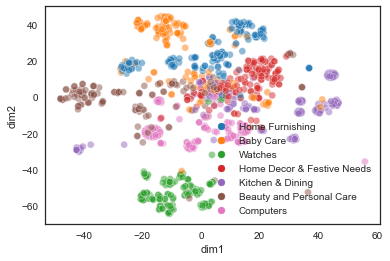

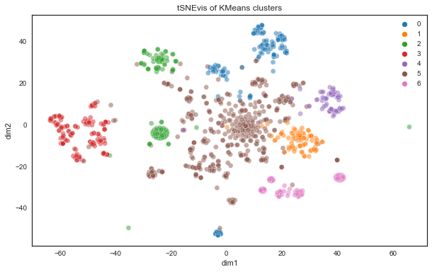

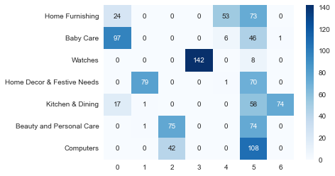

```
Cluster sizes
5    210
3    180
6    156
2    149
4    127
0    116
1    112
dtype: int64
ARI of labels from tSNE 0.43132155188529786
AMutual Info score of labels from tSNE 0.5320365003568461
Homogeneity score of labels from tSNE 0.5329599724541941
Completeness score of labels from tSNE 0.5395413949487741
Fowlkes Mallows score of labels from tSNE 0.5141753560063559
Silhouette score of labels from tSNE 0.09066501363226605
Davies-Bouldin index of labels from tSNE 4.0540551341064885
Calinski-Harabasz score of labels from tSNE 33.38786517355721
```

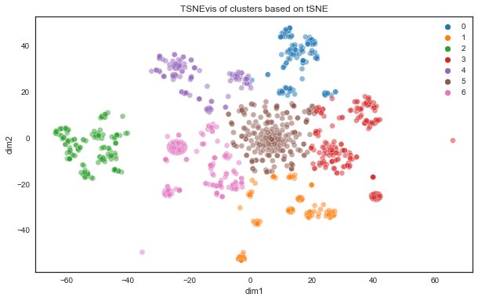

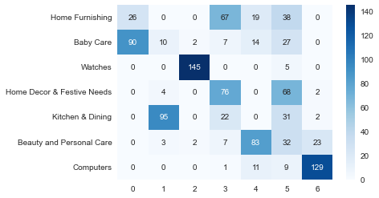

```python
greedy_vectorizer_pipeline('porter', 'greedy_tf_idf', comparison=False, pictures=True)
# greedy_vectorizer_pipeline('token', 'greedy_tf_idf', comparison=False, pictures=True)
# greedy_vectorizer_pipeline('lemma_pos', 'greedy_tf_idf', comparison=False, pictures=True)
# greedy_vectorizer_pipeline('lemma', 'greedy_count_vectorizer', comparison=False, pictures=True)
# greedy_vectorizer_pipeline('lemma', 'greedy_tf_idf', comparison=False, pictures=True)
# greedy_vectorizer_pipeline('porter', 'greedy_tf', comparison=False, pictures=True)
```

## Dimensionality reduction made with PCA

```python
count_vectorizer = CountVectorizer(min_df=0.01, max_df=0.29, max_features=None)
```

```python
tf_l1 = TfidfVectorizer(
    binary=False, norm='l1',
    use_idf=False, smooth_idf=False,
    lowercase=False, # stop_words='english', # don't need to apply these params
    min_df=5, max_df=0.33, max_features=None, ngram_range=(1,1) # default values
)

# this one is identical to CountVectorizer IN THE SPAN of 1 document
# but not BETWEEN DIFFERENT DOCUMENTS
# it's proportional to CountVectorier for any given document
# but what is the same number in different docs for CountVecto, is not for this configu of TfidfVecto
```

```python
tfidf_l2 = TfidfVectorizer(
    binary=False, norm='l2',
    use_idf=True, smooth_idf=True,
    lowercase=False, # stop_words='english', # don't need to apply these params
    min_df=5, max_df=0.29, max_features=None, ngram_range=(1,1) # default values
)

# this one is different from CountVecto in a span of 1 doc and also between the docs. default config of TfidfVecto
```

```python
tfidf_l2_bigrams = TfidfVectorizer(
    binary=False, norm='l2',
    use_idf=True, smooth_idf=True,
    lowercase=False, # stop_words='english', # don't need to apply these params
    min_df=5, max_df=0.29, max_features=None, ngram_range=(1,2) # default values
)

# this one is different from CountVecto in a span of 1 doc and also between the docs. default config of TfidfVecto
```

```python
# example_spa, example_arr = vectorize_pdseries(tfidf_l2_bigrams, descri.token)
example_spa, example_arr = vectorize_pdseries(descri.token, tfidf_l2)
print('Before StandardScaler, mins are:', example_spa.min(), example_arr.min(), 'maxes are:', example_spa.max(), example_arr.max())
example_arr_st = StandardScaler().fit_transform(example_arr)
print ('After StandardScaler, min:',example_arr_st.min(), 'max:', example_arr_st.max())
print('dataset shape before PCA: {}, first line length before PCA: {}'.format(example_arr_st.shape, example_arr_st[0].shape))


pca = PCA(n_components=0.95)
# pca.fit(example_arr)
example_pca_trans = pca.fit_transform(example_arr)
cumu_vari = pca.explained_variance_ratio_.cumsum()
# example_pca_trans = pca.transform(example_arr)
print('dataset shape after PCA: {}, first line length after PCA: {}'.format(example_pca_trans.shape, example_pca_trans[0].shape))
```

```
Before StandardScaler, mins are: 0.0 0.0 maxes are: 1.0 1.0
After StandardScaler, min: -0.5204966303372175 max: 31.314856028852176
dataset shape before PCA: (1050, 1155), first line length before PCA: (1155,)
dataset shape after PCA: (1050, 386), first line length after PCA: (386,)
```

D'après nombreux articles internet expliquants PCA, nous ne pouvons pas avoir plus que N-1 composants principals si nous avons N samples et p features et N < p. Il est donc inutile de transposer la matrice, j'ai éliminé ce bloc de code.

```python
# print('2 components:{:.2f}, 200 components:{:.2f}, 400 components: {:.2f}, 500 components: {:.2f}'.format(cumu_vari[2], cumu_vari[200], cumu_vari[250], cumu_vari[400], cumu_vari[500]))  # for lemma_pos stemmer and tf_idf vectorizer it's 9%, 74%, 80.2% et 91% respectively
# for token and bigrams it's 2 components:0.05, 200 components:0.53, 400 components: 0.58, 500 components: 0.72
```

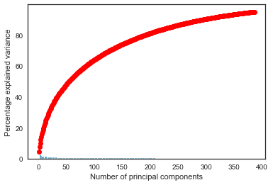

```python
scree = pca.explained_variance_ratio_*100
plt.bar(np.arange(len(scree))+1, scree)
plt.plot(np.arange(len(scree))+1, scree.cumsum(),c="red",marker='o')
plt.xlabel("Number of principal components")
plt.ylabel("Percentage explained variance")
# plt.title("Scree plot")
plt.show(block=False) # no difference with block=True. At least I don't see the difference
# plt.savefig(savepath+'pca', bbox_inches='tight')

# example_projected_pca = example_pca_trans[:, :500]
```